# Ecommerce Analysis

```python
import pandas as pd
import numpy as np
from matplotlib import pyplot as plt
%matplotlib inline
import seaborn as sns
```

```python
# Importing Ecommerce data set and viewing first 5 rows
data = pd.read_csv("ecommerce.csv")
print(data)
```

```
       Order_Date      Time  Age  Customer_Id  Gender Device_Type  \
0      2018-01-02  10:56:33   36        37077  Female         Web
1      2018-07-24  20:41:37   54        59173  Female         Web
2      2018-11-08  08:38:49   32        41066  Female         Web
3      2018-04-18  19:28:06   43        50741  Female         Web
4      2018-08-13  21:18:39   48        53639  Female         Web
...           ...       ...  ...          ...     ...         ...
51285  2018-02-28  22:59:50   19        78489  Female      Mobile
51286  2018-02-28  13:19:25   40        91941  Female      Mobile
51287  2018-02-28  10:25:07   24        63313    Male         Web
51288  2018-02-28  10:50:08   47        86485    Male         Web
51289  2018-02-28  11:09:40   50        81129    Male         Web

      Customer_Login_type    Product_Category            Product  Sales  \
0                  Member  Auto & Accessories  Car Media Players  140.0
```

[output cut: 38 more lines]

```python
# Descriptive statistics from the data
data.describe()
```

|  | Age | Customer_Id | Sales | Quantity | Discount | Profit | Shipping_Cost |
| --- | --- | --- | --- | --- | --- | --- | --- |
| count | 51290.000000 | 51290.000000 | 51289.000000 | 51288.000000 | 51289.000000 | 51290.000000 | 51289.000000 |
| mean | 41.428329 | 58155.758764 | 152.340872 | 2.502983 | 0.303821 | 70.407226 | 7.041557 |
| std | 13.885526 | 26032.215826 | 66.495419 | 1.511859 | 0.131027 | 48.729488 | 4.871745 |
| min | 18.000000 | 10000.000000 | 33.000000 | 1.000000 | 0.100000 | 0.500000 | 0.100000 |
| 25% | 29.000000 | 35831.250000 | 85.000000 | 1.000000 | 0.200000 | 24.900000 | 2.500000 |
| 50% | 41.000000 | 61018.000000 | 133.000000 | 2.000000 | 0.300000 | 59.900000 | 6.000000 |
| 75% | 53.000000 | 80736.250000 | 218.000000 | 4.000000 | 0.400000 | 118.400000 | 11.800000 |
| max | 65.000000 | 99999.000000 | 250.000000 | 5.000000 | 0.500000 | 167.500000 | 16.800000 |

```python
data.dtypes
```

```
Order_Date              object
Time                    object
Age                      int64
Customer_Id              int64
Gender                  object
Device_Type             object
Customer_Login_type     object
Product_Category        object
Product                 object
Sales                  float64
Quantity               float64
Discount               float64
Profit                 float64
Shipping_Cost          float64
Order_Priority          object
Payment_method          object
MKTG_Channel            object
dtype: object
```

```python
# Data Cleaning
```

```python
data.info()
```

```
<class 'pandas.core.frame.DataFrame'>
RangeIndex: 51290 entries, 0 to 51289
Data columns (total 17 columns):
 #   Column               Non-Null Count  Dtype
---  ------               --------------  -----
 0   Order_Date           51290 non-null  object
 1   Time                 51290 non-null  object
 2   Age                  51290 non-null  int64
 3   Customer_Id          51290 non-null  int64
 4   Gender               51290 non-null  object
 5   Device_Type          51290 non-null  object
 6   Customer_Login_type  51290 non-null  object
 7   Product_Category     51290 non-null  object
 8   Product              51290 non-null  object
 9   Sales                51289 non-null  float64
 10  Quantity             51288 non-null  float64
 11  Discount             51289 non-null  float64
 12  Profit               51290 non-null  float64
 13  Shipping_Cost        51289 non-null  float64
 14  Order_Priority       51288 non-null  object
 15  Payment_method       51290 non-null  object
 16  MKTG_Channel         51290 non-null  object
dtypes: float64(5), int64(2), object(10)
memory usage: 6.7+ MB
```

```python
# Removing Null Values
data = data.dropna()
data.info()
```

```
<class 'pandas.core.frame.DataFrame'>
Index: 51283 entries, 0 to 51289
Data columns (total 17 columns):
 #   Column               Non-Null Count  Dtype
---  ------               --------------  -----
 0   Order_Date           51283 non-null  object
 1   Time                 51283 non-null  object
 2   Age                  51283 non-null  int64
 3   Customer_Id          51283 non-null  int64
 4   Gender               51283 non-null  object
 5   Device_Type          51283 non-null  object
 6   Customer_Login_type  51283 non-null  object
 7   Product_Category     51283 non-null  object
 8   Product              51283 non-null  object
 9   Sales                51283 non-null  float64
 10  Quantity             51283 non-null  float64
 11  Discount             51283 non-null  float64
 12  Profit               51283 non-null  float64
 13  Shipping_Cost        51283 non-null  float64
 14  Order_Priority       51283 non-null  object
 15  Payment_method       51283 non-null  object
 16  MKTG_Channel         51283 non-null  object
dtypes: float64(5), int64(2), object(10)
memory usage: 7.0+ MB
```

```python
# Converting Age from float to integer

data['Age'] = data['Age'].astype(int)
data.dtypes
```

```
Order_Date              object
Time                    object
Age                      int64
Customer_Id              int64
Gender                  object
Device_Type             object
Customer_Login_type     object
Product_Category        object
Product                 object
Sales                  float64
Quantity               float64
Discount               float64
Profit                 float64
Shipping_Cost          float64
Order_Priority          object
Payment_method          object
MKTG_Channel            object
dtype: object
```

```python
# Converting Date from Object to Date type
data['Order_Date'] = pd.to_datetime(data['Order_Date'], errors='coerce').dt.date
data.dtypes
```

```
Order_Date              object
Time                    object
Age                      int64
Customer_Id              int64
Gender                  object
Device_Type             object
Customer_Login_type     object
Product_Category        object
Product                 object
Sales                  float64
Quantity               float64
Discount               float64
Profit                 float64
Shipping_Cost          float64
Order_Priority          object
Payment_method          object
MKTG_Channel            object
dtype: object
```

```python
# Explanatory Analysis
```

```python
# Breakdown of Different Product Categories
product_categories = data['Product_Category'].value_counts()
product_categories
```

```
Product_Category
Fashion               25646
Home & Furniture      15438
Auto & Accessories     7498
Electronic             2701
Name: count, dtype: int64
```

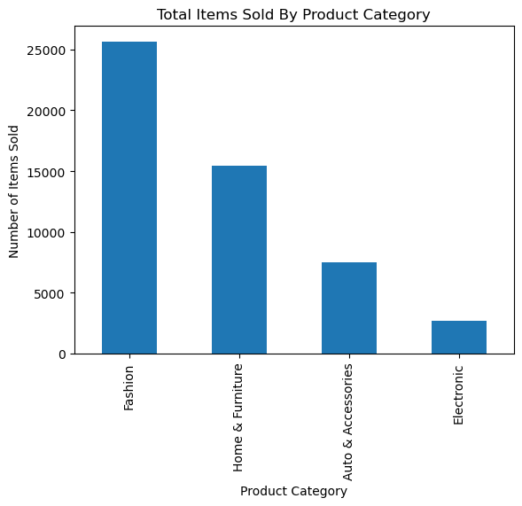

```python
# Graph of Product Categories Sold
product_categories_graph = product_categories.plot.bar(x='Product Category', y='Total Items Sold', rot=90, title='Total Items Sold By Product Category')

# Adding labels and title
plt.xlabel('Product Category')
plt.ylabel('Number of Items Sold')
plt.title('Total Items Sold By Product Category')
```

```python
# Sales in Dollars by Product Category
Product_sales = data.groupby('Product_Category')['Sales'].sum().sort_values(ascending=False)
Product_sales
```

```
Product_Category
Fashion               4345914.0
Home & Furniture      1975831.0
Auto & Accessories    1095821.0
Electronic             394738.0
Name: Sales, dtype: float64
```

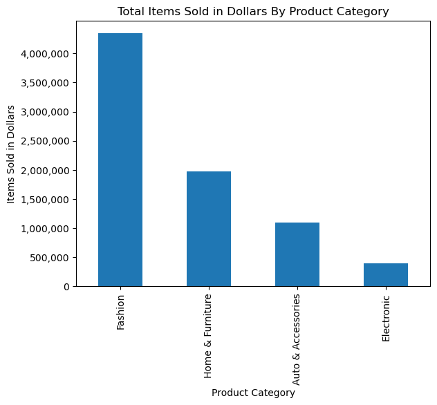

```python
# Graph of Sales in Dollars by Product Category
Product_sales_graph = Product_sales.plot.bar(x='Product Category', y='Items Sold in Dollars', rot=90, title='Total Items Sold in Dollars By Product Category')

# Adding labels and title
plt.xlabel('Product Category')
plt.ylabel('Items Sold in Dollars')
plt.title('Total Items Sold in Dollars By Product Category')

# Disable scientific notation
plt.gca().get_yaxis().get_major_formatter().set_scientific(False)

# Set y ticks to start from 0 and go up to 4,500,000 in increments of 500,000
y_ticks = np.arange(0, 4500000, 500000)
plt.yticks(y_ticks, [f'{int(val):,}' for val in y_ticks])


# Adjust layout to prevent overlapping and increase space between ticks
plt.tight_layout()
plt.subplots_adjust(left=0.1, right=0.9, top=0.9, bottom=0.1)
```

```python
# Analyzing Different Age Groups To Put Them Into Bins
# Bins will be: Gen Z, Millennials, Gen X & Baby Boomers

data['Age'].describe()
```

```
count    51283.000000
mean        41.427881
std         13.885263
min         18.000000
25%         29.000000
50%         41.000000
75%         53.000000
max         65.000000
Name: Age, dtype: float64
```

```python
# Define bins as (0 - 25, 26 - 41, 42 - 57, 58 - 76)
bins = [0, 25, 41, 57, 76]

# Group Names For Bins
group_names = ["Gen Z", "Millennials", "Gen X", "Baby Boomers"]

# Adding New Age Bucket Column
data['Age_Buckets'] = pd.cut(data['Age'], bins, labels=group_names)
```

```python
# Total Purchases by Age Group
Age_Purchases = data['Age_Buckets'].value_counts()
Age_Purchases
```

```
Age_Buckets
Gen X           17157
Millennials     16959
Gen Z            8711
Baby Boomers     8456
Name: count, dtype: int64
```

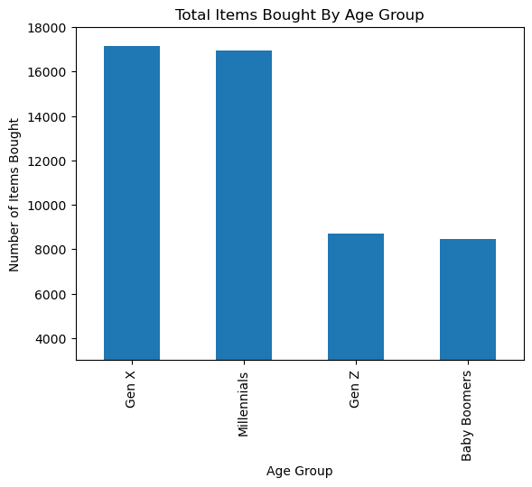

```python
# Graph of Number of Purchases by Age Group
Age_Purchases_Graph = Age_Purchases.plot.bar(x='Age_Purchases', ylim=3000, rot=90, title='Amount of Purchases By Age Group')

# Adding labels and title
plt.xlabel('Age Group')
plt.ylabel('Number of Items Bought')
plt.title('Total Items Bought By Age Group')
```

```python
# Sales in Dollars by Product Category
Age_sales = data.groupby('Age_Buckets')['Sales'].sum().sort_values(ascending=False)
Age_sales
```

```
Age_Buckets
Gen X           2619009.0
Millennials     2570408.0
Gen Z           1330427.0
Baby Boomers    1292460.0
Name: Sales, dtype: float64
```

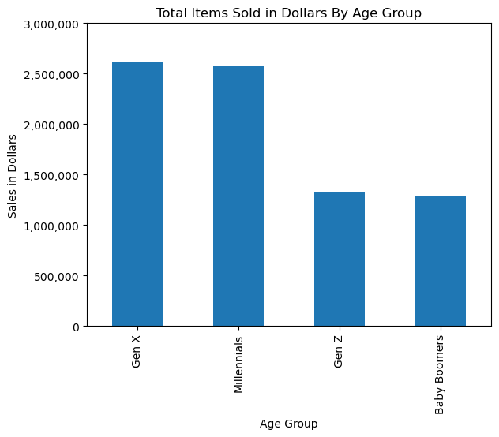

```python
# Graph of Sales in Dollars by Age Group
Age_sales_Graph = Age_sales.plot.bar(x='Age_sales', y='Items Sold in Dollars', rot=90, title='Total Items Sold in Dollars By Age Group')

# Adding labels and title
plt.xlabel('Age Group')
plt.ylabel('Sales in Dollars')
plt.title('Total Items Sold in Dollars By Age Group')

# Disable scientific notation
plt.gca().get_yaxis().get_major_formatter().set_scientific(False)

# Set y ticks to start from 0 and go up to 3,000,000 in increments of 500,000
y_ticks = np.arange(0, 3500000, 500000)
plt.yticks(y_ticks, [f'{int(val):,}' for val in y_ticks])


# Adjust layout to prevent overlapping and increase space between ticks
plt.tight_layout()
plt.subplots_adjust(left=0.1, right=0.9, top=0.9, bottom=0.1)
```

```python
# Sales in Dollars by Marketing Channel
MKTG_sales = data.groupby('MKTG_Channel')['Sales'].sum().sort_values(ascending=False)
MKTG_sales
```

```
MKTG_Channel
Organic     1572991.0
Facebook    1571728.0
Email       1559728.0
Youtube     1558394.0
Adwords     1549463.0
Name: Sales, dtype: float64
```

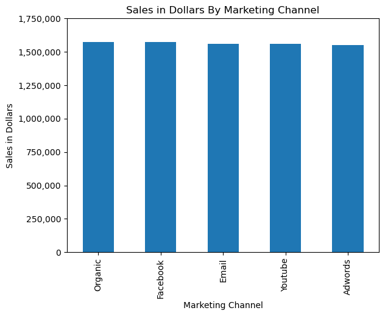

```python
# Graph of Sales in Dollars by Marketing Channel
MKTG_sales_graph = MKTG_sales.plot.bar(x='MKTG_sales', ylim=3000, rot=90, title='Sales in Dollars By Marketing Channel')

# Adding labels and title
plt.xlabel('Marketing Channel')
plt.ylabel('Sales in Dollars')
plt.title('Sales in Dollars By Marketing Channel')

# Disable scientific notation
plt.gca().get_yaxis().get_major_formatter().set_scientific(False)

# Set y ticks to start from 0 and go up to 2,000,000 in increments of 250,000
y_ticks = np.arange(0, 2000000, 250000)
plt.yticks(y_ticks, [f'{int(val):,}' for val in y_ticks])


# Adjust layout to prevent overlapping and increase space between ticks
plt.tight_layout()
plt.subplots_adjust(left=0.1, right=0.9, top=0.9, bottom=0.1)
```

```python
# Logistic Regression
!pip install statsmodels pandas
import statsmodels.api as sm
```

```python
# Predicting the probability of purchasing each product category
```

```python
# creating dummy variable for product category
# Use get_dummies to create binary columns for each product category
product_category_dummies = pd.get_dummies(data['Product_Category'])

# Concatenate the new binary columns with the original DataFrame
data = pd.concat([data, product_category_dummies], axis=1)
```

```python
# renaming column names for easier access
column_mapping = {'Auto & Accessories': 'Auto', 'Home & Furniture': 'Home_furniture'}
data = data.rename(columns=column_mapping)
```

```python
# creating dummy variable for mktg channels
# Use get_dummies to create binary columns for each product category
mktg_channel_dummies = pd.get_dummies(data['MKTG_Channel'])

# Concatenate the new binary columns with the original DataFrame
data = pd.concat([data, mktg_channel_dummies], axis=1)
```

```python
# creating dummy variable for gender
# Replace 'Male' with 0 and 'Female' with 1 in the 'Gender' column
data['Gender'] = data['Gender'].replace({'Male': 0, 'Female': 1})
```

```python
# creating dummy variable for device type
# Replace 'Web' with 1 and 'Mobile' with 0 in the 'device_type' column
data['Device_Type'] = data['Device_Type'].replace({'Web': 1, 'Mobile': 0})
```

```python
# creating dummy variable for customer log in type
# Use get_dummies to create binary columns for each log in type
customer_dummies = pd.get_dummies(data['Customer_Login_type'])

# Concatenate the new binary columns with the original DataFrame
data = pd.concat([data, customer_dummies], axis=1)

# renaming first sign up
column_mapping1 = {'First SignUp': 'FirstSignUp'}
data = data.rename(columns=column_mapping1)

# renaming New column
column_mapping2 = {'New ': 'New'}
data = data.rename(columns=column_mapping2)
```

```python
# List of columns to convert
columns_to_convert = ['Auto', 'Electronic', 'Fashion', 'Home_furniture', 'Adwords', 'Email', 'Facebook', 'Organic',
                     'Youtube', 'FirstSignUp', 'Guest', 'Member', 'New']

# Iterate through columns and convert boolean values to integers
for column in columns_to_convert:
    data[column] = data[column].astype(int)
```

```python
# Logistic Regression for Electronic Category

y = data['Electronic']
X = data[[ 'Age', 'Gender', 'FirstSignUp']]

# Add a constant term to the features (required for statsmodels)
X = sm.add_constant(X)

# Create a logistic regression model
logreg = sm.Logit(y, X)

# Fit the model
result = logreg.fit()

# Display the summary of the model
print(result.summary())
```

```
Optimization terminated successfully.
         Current function value: 0.203822
         Iterations 7
                           Logit Regression Results
==============================================================================
Dep. Variable:             Electronic   No. Observations:                51283
Model:                          Logit   Df Residuals:                    51279
Method:                           MLE   Df Model:                            3
Date:                Thu, 14 Dec 2023   Pseudo R-squ.:                 0.01200
Time:                        20:38:13   Log-Likelihood:                -10453.
converged:                       True   LL-Null:                       -10580.
Covariance Type:            nonrobust   LLR p-value:                 8.858e-55
===============================================================================
                  coef    std err          z      P>|z|      [0.025      0.975]
-------------------------------------------------------------------------------
const          -2.9514      0.065    -45.166      0.000      -3.079      -2.823
Age            -0.0037      0.001     -2.566      0.010      -0.006      -0.001
Gender          0.3887      0.040      9.725      0.000       0.310       0.467
FirstSignUp     2.1929      0.161     13.650      0.000       1.878       2.508
===============================================================================
```

# Logisitic Regression analyzing the significant variables in purchasing an item for the electronic category.

Model Interpretation: Constant- When all other coeffecients are 0 or not present the odds of purchasing an electronic decreases by exp(-2.9514) or 94.78%

Age- A 1 year increase in age decreases the odds of buying an electronic by exp(-0.0037) or 0.37% keeping everything else constant.

Gender- With 1 representing female, the odds of purchasing an electronic increases by exp(0.3887) or 47.59% if the customer is a female.

FirstSignUp- When a customer logs in as a first sign up for the ecommerce store, the odds of purchasing an electronic increases by exp(2.1929) or 796.52%.

Note: Marketing Channel variables (Facebook, Email, Youtube, Adwords & Organic) all proved to be insignificant predictors of purchase probability

Device Type proved to be a significant variable with a small p-value, however, its standard error and confidence inerval was large.

```python
# Logistic Regression for Fashion Category

y = data['Fashion']
X = data[[ 'Age', 'Gender', 'New', 'Device_Type']]

# Add a constant term to the features (required for statsmodels)
X = sm.add_constant(X)

# Create a logistic regression model
logreg = sm.Logit(y, X)

# Fit the model
result = logreg.fit()

# Display the summary of the model
print(result.summary())
```

```
Optimization terminated successfully.
         Current function value: 0.689716
         Iterations 5
                           Logit Regression Results
==============================================================================
Dep. Variable:                Fashion   No. Observations:                51283
Model:                          Logit   Df Residuals:                    51278
Method:                           MLE   Df Model:                            4
Date:                Thu, 14 Dec 2023   Pseudo R-squ.:                0.004951
Time:                        20:45:05   Log-Likelihood:                -35371.
converged:                       True   LL-Null:                       -35547.
Covariance Type:            nonrobust   LLR p-value:                 6.639e-75
===============================================================================
                  coef    std err          z      P>|z|      [0.025      0.975]
-------------------------------------------------------------------------------
const           0.5689      0.044     12.826      0.000       0.482       0.656
Age             0.0013      0.001      2.048      0.041    5.64e-05       0.003
Gender         -0.0801      0.018     -4.494      0.000      -0.115      -0.045
New             1.2324      0.465      2.650      0.008       0.321       2.144
Device_Type    -0.6310      0.036    -17.666      0.000      -0.701      -0.561
===============================================================================
```

# Logisitic Regression analyzing the significant variables in purchasing an item from the fashion category.

Age- A 1 year increase in age increases the odds of buying a fashion item by exp(0.0013) or 0.13% keeping everything else constant.

Gender- With 1 representing female, the odds of purchasing a fashion item decreases by exp(-0.0801) or 7.63% if the customer is a female.

New- When a customer logs in as a new customer, the odds of purchasing a fashion item increases by exp(1.2324) or 242.93%.

Device Type- With 1 representing log in by web/computer, the odds of purchasing a fashion item decreases by exp(-0.6310) or 46.73% when a customer logged in by a computer compared to mobile.

Note: Marketing Channel variables (Facebook, Email, Youtube, Adwords & Organic) all proved to be insignificant predictors of purchase probability

```python
# Logistic Regression for Auto and Accessory Category

y = data['Auto']
X = data[[ 'Age', 'Gender', 'Member']]

# Add a constant term to the features (required for statsmodels)
X = sm.add_constant(X)

# Create a logistic regression model
logreg = sm.Logit(y, X)

# Fit the model
result = logreg.fit()

# Display the summary of the model
print(result.summary())
```

```
Optimization terminated successfully.
         Current function value: 0.408793
         Iterations 6
                           Logit Regression Results
==============================================================================
Dep. Variable:                   Auto   No. Observations:                51283
Model:                          Logit   Df Residuals:                    51279
Method:                           MLE   Df Model:                            3
Date:                Thu, 14 Dec 2023   Pseudo R-squ.:                 0.01750
Time:                        21:04:25   Log-Likelihood:                -20964.
converged:                       True   LL-Null:                       -21338.
Covariance Type:            nonrobust   LLR p-value:                1.393e-161
==============================================================================
                 coef    std err          z      P>|z|      [0.025      0.975]
------------------------------------------------------------------------------
const         -1.5940      0.074    -21.614      0.000      -1.739      -1.449
Age           -0.0019      0.001     -2.141      0.032      -0.004      -0.000
Gender        -0.7078      0.027    -26.439      0.000      -0.760      -0.655
Member         0.1940      0.065      2.997      0.003       0.067       0.321
==============================================================================
```

# Logisitic Regression analyzing the significant variables in purchasing an item from the Auto & Accessory category

Model Interpretation: Constant- When all other coeffecients are 0 or not present the odds of purchasing an auto and accessory item decreases by exp(-1.5940) or 79.63%

Age- A 1 year increase in age decreases the odds of buying an auto and accessory item by exp(-0.0019) or 0.19% keeping everything else constant.

Gender- With 1 representing female, the odds of purchasing an auto and accessory decreases by exp(-0.7078) or 50.67% if the customer is a female.

Member- When a customer logs in as a member, the odds of purchasing an auto and accessory item increases by exp(0.1940) or 21.37%.

Note:

Marketing Channel variables (Facebook, Email, Youtube, Adwords & Organic) all proved to be insignificant predictors of purchase probability

Device Type proved to be not significant

```python
# Logistic Regression for Home & Furniture Category

y = data['Home_furniture']
X = data[[ 'Age', 'Gender', 'FirstSignUp', 'Device_Type']]

# Add a constant term to the features (required for statsmodels)
X = sm.add_constant(X)

# Create a logistic regression model
logreg = sm.Logit(y, X)

# Fit the model
result = logreg.fit()

# Display the summary of the model
print(result.summary())
```

```
Optimization terminated successfully.
         Current function value: 0.607282
         Iterations 6
                           Logit Regression Results
==============================================================================
Dep. Variable:         Home_furniture   No. Observations:                51283
Model:                          Logit   Df Residuals:                    51278
Method:                           MLE   Df Model:                            4
Date:                Thu, 14 Dec 2023   Pseudo R-squ.:                0.007285
Time:                        21:07:13   Log-Likelihood:                -31143.
converged:                       True   LL-Null:                       -31372.
Covariance Type:            nonrobust   LLR p-value:                 1.263e-97
===============================================================================
                  coef    std err          z      P>|z|      [0.025      0.975]
-------------------------------------------------------------------------------
const          -0.8007      0.046    -17.321      0.000      -0.891      -0.710
Age             0.0005      0.001      0.761      0.447      -0.001       0.002
Gender          0.3766      0.019     19.443      0.000       0.339       0.415
FirstSignUp    -0.9528      0.207     -4.600      0.000      -1.359      -0.547
Device_Type    -0.2571      0.036     -7.127      0.000      -0.328      -0.186
===============================================================================
```

# Logisitic Regression analyzing the significant variables in purchasing an item from the Home & Furniture category

Model Interpretation: Constant- When all other coeffecients are 0 or not present the odds of purchasing a home and furniture item decreases by exp(-0.8007) or 55.05%

Age- A 1 year increase in age increases the odds of buying a home and furniture item by exp(0.0005) or 0.05% keeping everything else constant.

Gender- With 1 representing female, the odds of purchasing a home and furniture item increases by exp(0.3766) or 45.75% if the customer is a female.

FirstSignUp- When a customer logs in as a first time sign up, the odds of purchasing a home and furniture item decreases by exp(-0.9528) or 61.46%.

Device Type- With 1 representing web/computer, when a customer logs in by web/computer the odds of purchasing a home and furniture items decreases by exp(-0.2571) or 22.65%.

Note:

Marketing Channel variables (Facebook, Email, Youtube, Adwords & Organic) all proved to be insignificant predictors of purchase probability.